# Mojave_Div_ITS_phyloseq

Nat Pombubpa

###STEP1: Load all necessary packages for analysis More information about Phyloseq can be found at the following link: [Phyloseq](https://joey711.github.io/phyloseq/) If you get error in this step, you probably need to install any packages which causes error.

```r
library(ape)
library(vegan)
library(dplyr)
library(scales)
library(grid)
library(reshape2)
library(phyloseq)
library(magrittr)
library(ggplot2)
library(ggpubr)
library(plyr)
library(data.table)
library(tidyr)
library(tidyverse)
```

###STEP2: Import Mapping file (metadate file) 1.Check mapping file before import to R, R doesn’t seem to like sample name to start with number or contain “-” in sample name. If you get error in this step, you should check file name first.

2.First column of first row should not start with #, R will not read the first row that starts with #

3. You can choose which samples to include in analysis by indicating “KEEP” in Description column

```r
meta = read.table("metadata_khk.tsv",header=TRUE,row.names=1,sep="\t",stringsAsFactors=FALSE)
```

If need to keep or remove some samples

```r
#meta <- meta[which(meta$Layer %in% c("Surface")),]
```

###STEP3: Check if your metadata file has been import successfully and correctly

The output will show a table of your metadata file (mapping file).

*If you do not have header, you might start your first row with #

```r
head(meta)
```

```
##                    SampleID_2 Locus Flowcell Site Site_layer      Layer
## AlphaA1.TR.1     AlphaA1.TR.1   ITS       NA   AB     AB_Sub Subsurface
## AlphaB1.TR.2     AlphaB1.TR.2   ITS       NA   AB      AB_SF    Surface
## AlphaB3.TR.2     AlphaB3.TR.2   ITS       NA   AB      AB_SF    Surface
## AlphaB4.TR.1     AlphaB4.TR.1   ITS       NA   AB      AB_SF    Surface
## AlphaB5.TR.2.1 AlphaB5.TR.2.1   ITS       NA   AB      AB_SF    Surface
## AlphaB5.TR.2.2 AlphaB5.TR.2.2   ITS       NA   AB      AB_SF    Surface
##                Soil_type Soil_type_layer Crust_type Sampling_month
## AlphaA1.TR.1     Granite     Granite_Sub    SMC.Sub             NA
## AlphaB1.TR.2     Granite      Granite_SF        SMC             NA
## AlphaB3.TR.2     Granite      Granite_SF        SMC             NA
## AlphaB4.TR.1     Granite      Granite_SF        SMC             NA
## AlphaB5.TR.2.1   Granite      Granite_SF        SMC             NA
## AlphaB5.TR.2.2   Granite      Granite_SF        SMC             NA
##                Sampling_Date
## AlphaA1.TR.1              NA
## AlphaB1.TR.2              NA
## AlphaB3.TR.2              NA
## AlphaB4.TR.1              NA
## AlphaB5.TR.2.1            NA
## AlphaB5.TR.2.2            NA
```

###STEP4: Construct sample_data-class using imported metadata

```r
sampleData <- sample_data(meta)
```

###STEP5: Import OTU table

```r
otus <- read.table("Mojave2020_KKelly202307.otu_table.txt",header=T,sep="\t",row.names=1)
otumat <- as(as.matrix(otus), "matrix")
OTU = otu_table(otumat, taxa_are_rows = TRUE)
```

Check imported OTU table

```r
head(OTU)
```

```
## OTU Table:          [6 taxa and 77 samples]
##                      taxa are rows
##          AlphaA1.TR.1 AlphaB1.TR.2 AlphaB3.TR.2 AlphaB4.TR.1 AlphaB5.TR.2.1
## ASV1                0            0            0            0              0
## ASV10               0            0            0            2              0
## ASV100              0            0            0            0              0
## ASV1000             0            0            0            0              0
## ASV10000            0            0            0            0              0
## ASV10001            3            0            1            2              1
##          AlphaB5.TR.2.2 AlphaC2.TR.2 AlphaC4.TR.2 AlphaD2.TR.1 AlphaD2.TR.2
## ASV1                  0            0            0            0            0
## ASV10                 0            0            0            1            0
## ASV100                0            0            0            0            0
## ASV1000               0            0            0            0            0
## ASV10000              0            0            0            0            0
## ASV10001              2            1            1            2            1
##          AlphaD3.TR.2 BetaA3.TR.2 BetaB1.TR.1 BetaB2.TR.2 BetaC1.TR.2
## ASV1                0           0           0           0           0
## ASV10               4           0           0           0           0
## ASV100              0           0           0           0           0
## ASV1000             0           0           0           0           0
## ASV10000            0           0           0           1           0
## ASV10001            3           1           0           0           1
##          BetaC2.TR.2 BetaD1.TR.1 BetaD2.TR.1 GammaA5.TR.2 GammaB1.TR.1
## ASV1               0           0           0            0            0
## ASV10              2           0           2            0            0
## ASV100             0           0           0            0            0
## ASV1000            0           0           0            0            0
## ASV10000           0           1           0            0            0
## ASV10001           0           4           1            1            0
##          GammaB4.TR.2 GammaB5.TR.2 GammaC2.TR.2.1 GammaC2.TR.2.2 GammaC3.TR.1
## ASV1                0            0              0              0            0
## ASV10            8649            0              1              0            0
## ASV100              0            0              0              0            0
## ASV1000             0            0              0              0            0
## ASV10000            0            0              0              0            1
## ASV10001            1            1              1              0            2
##          GammaD4.TR.2 GammaD5.TR.2 NEGATIVE SRR9106059 SRR9106060 SRR9106061
## ASV1                0            0        0         63       5408      24134
## ASV10               4            8        0         13         29        750
```

[output cut: 45 more lines]

```
## ASV10001          0          3          0          0          1          0
##          SRR9106098 SRR9106099 SRR9106100 SRR9106101 SRR9106102 SRR9106103
## ASV1           7339      56232       7313      29728        177       7735
## ASV10           256         26      24431          6          7         20
## ASV100            1        329         12          8          3       3446
## ASV1000           0          2          1          3          2          0
## ASV10000          0          0          0          0          0          1
## ASV10001          0          1          1          0          1          1
##          SRR9106104 SRR9106105 SRR9106106 TAPWATER
## ASV1           2461       6613      29410        0
## ASV10            17          1         10        0
## ASV100         1187        123          0        0
## ASV1000           0         11          4        0
## ASV10000          1          0          0        0
## ASV10001          1          2          1        2
```

###STEP6: Import taxonomy table Taxonmy table generated from AMPtk need to be rearranged using following script.

“perl rdp_taxonmy2mat.pl<Input_taxonmy.txt>Output_taxonomy.txt”

rdp_taxonomy2mat.pl was created by Professor Jason E. Stajich

```r
taxmat <- read.table("Mojave2020_KKelly202307.ASVs.taxonomy.fix.txt", header=T,sep="\t",row.names=1)
taxmat <- as(as.matrix(taxmat),"matrix")
TAX = tax_table(taxmat)
```

###STEP7: Import phylogenetic tree Phylogenetic tree can also be include for further phylogenetic analysis.

```r
#treefile = "Mojave2020_KKelly202307.ASVs.tree.phy"
#tree = read.tree(treefile)
```

###STEP8: Construct Phyloseq object To construct phyloseq object, otu table, taxonomy table, and sampleData are required. Phylogenetic tree can be included, but it is not necessary for constructing phyloseq object. Construct Phyloseq object called “Physeq”

```r
physeq = phyloseq(OTU,TAX,sampleData)
```

Check phyloseq object This should indicate that your physeq is a “phyloseq-class experiment-level object””

```r
physeq
```

```
## phyloseq-class experiment-level object
## otu_table()   OTU Table:         [ 30109 taxa and 22 samples ]
## sample_data() Sample Data:       [ 22 samples by 11 sample variables ]
## tax_table()   Taxonomy Table:    [ 30109 taxa by 7 taxonomic ranks ]
```

###STEP9: Remove singletons Remove any OTUs that present only one time.

```r
physeq.prune = prune_taxa(taxa_sums(physeq) > 1, physeq)
```

```r
physeq.prune
```

```
## phyloseq-class experiment-level object
## otu_table()   OTU Table:         [ 5502 taxa and 22 samples ]
## sample_data() Sample Data:       [ 22 samples by 11 sample variables ]
## tax_table()   Taxonomy Table:    [ 5502 taxa by 7 taxonomic ranks ]
```

###STEP10: Plot read counts to check dataset Check read counts: any samples that have very low reads should be removed. [Ref](http://evomics.org/wp-content/uploads/2016/01/phyloseq-Lab-01-Answers.html)

```r
readcount = data.table(as(sample_data(physeq.prune), "data.frame"),
                 TotalReads = sample_sums(physeq.prune),
                 keep.rownames = TRUE)
setnames(readcount, "rn", "SampleID")

#For plotting, use command below.
#SeqDepth = ggplot(readcount, aes(TotalReads)) + geom_histogram() + ggtitle("Sequencing Depth")
```

```r
readcount = readcount[order(readcount$TotalReads), c("SampleID", "TotalReads")]
```

```r
head(readcount)
```

```
##          SampleID TotalReads
## 1: GammaC2.TR.2.1       7909
## 2:   GammaC3.TR.1       8733
## 3:   GammaD5.TR.2      29999
## 4:    BetaB2.TR.2      35612
## 5:   AlphaB1.TR.2      38906
## 6:   AlphaC4.TR.2      40730
```

```r
set.seed(1)
physeq.prune.rarefy = rarefy_even_depth(physeq.prune, sample.size = 7909, replace = FALSE, trimOTUs = FALSE)
```

```
## You set `rngseed` to FALSE. Make sure you've set & recorded
##  the random seed of your session for reproducibility.
## See `?set.seed`
```

```
## ...
```

```r
physeq.prune.rarefy
```

```
## phyloseq-class experiment-level object
## otu_table()   OTU Table:         [ 5502 taxa and 22 samples ]
## sample_data() Sample Data:       [ 22 samples by 11 sample variables ]
## tax_table()   Taxonomy Table:    [ 5502 taxa by 7 taxonomic ranks ]
```

###STEP11: Beta diversity

```r
ps.dist = phyloseq::distance(physeq.prune, "bray")
```

```r
adonis(ps.dist ~ Site*Layer*Crust_type, as(sample_data(physeq.prune),"data.frame"))
```

```
## 'adonis' will be deprecated: use 'adonis2' instead
```

```
## $aov.tab
## Permutation: free
## Number of permutations: 999
##
## Terms added sequentially (first to last)
##
##                 Df SumsOfSqs MeanSqs F.Model      R2 Pr(>F)
## Site             2    2.4922 1.24608  5.1618 0.29664  0.001 ***
## Layer            1    0.2881 0.28809  1.1934 0.03429  0.211
## Crust_type       2    1.3683 0.68417  2.8342 0.16287  0.001 ***
## Site:Layer       2    0.4720 0.23600  0.9776 0.05618  0.512
## Site:Crust_type  2    0.8839 0.44195  1.8308 0.10521  0.002 **
## Residuals       12    2.8968 0.24140         0.34481
## Total           21    8.4013                 1.00000
## ---
```

[output cut: 1241 more lines]

```r
adonis(ps.dist ~ Crust_type, as(sample_data(physeq.prune),"data.frame"))
```

```
## 'adonis' will be deprecated: use 'adonis2' instead
```

```
## $aov.tab
## Permutation: free
## Number of permutations: 999
##
## Terms added sequentially (first to last)
##
##            Df SumsOfSqs MeanSqs F.Model      R2 Pr(>F)
## Crust_type  3    1.7116 0.57053  1.5351 0.20373  0.013 *
## Residuals  18    6.6897 0.37165         0.79627
## Total      21    8.4013                 1.00000
## ---
## Signif. codes:  0 '***' 0.001 '**' 0.01 '*' 0.05 '.' 0.1 ' ' 1
##
## $call
## adonis(formula = ps.dist ~ Crust_type, data = as(sample_data(physeq.prune),
```

[output cut: 1080 more lines]

```r
physeq.prune.x = prune_taxa(taxa_sums(physeq.prune.rarefy) > 1, physeq.prune.rarefy)
physeq.prune.x.ord <- ordinate(physeq.prune.x, "PCoA", "bray")
```

```
## Too few points to calculate an ellipse
## Too few points to calculate an ellipse
## Too few points to calculate an ellipse
```

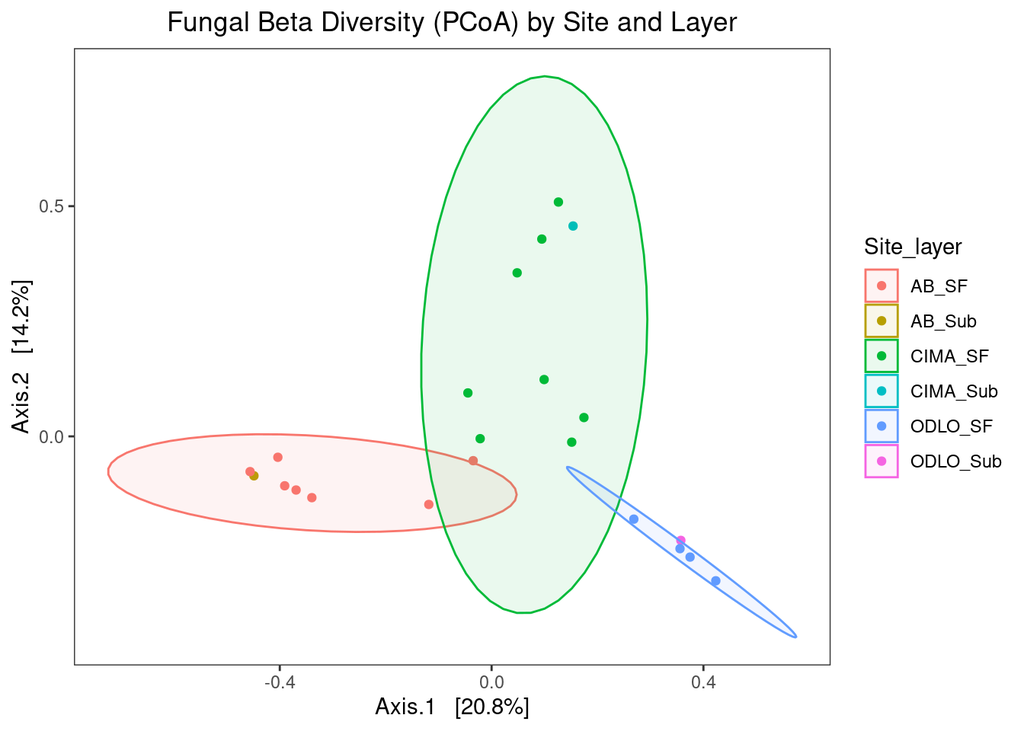

```r
pssitelayer = plot_ordination(physeq.prune.x, physeq.prune.x.ord, type = "samples", color = "Site_layer") + theme_bw() + ggtitle("Fungal Beta Diversity (PCoA) by Site and Layer") + theme(plot.title = element_text(hjust = 0.5)) + stat_ellipse(geom = "polygon", alpha = 1/12, aes(fill = Site_layer)) + theme(panel.grid.major = element_blank(), panel.grid.minor = element_blank())

pssitelayer
```

```r
pdf("./Figures/Fungal Beta Diversity (PCoA) by Site and Layer.pdf")
pssitelayer
```

```
## Too few points to calculate an ellipse
## Too few points to calculate an ellipse
## Too few points to calculate an ellipse
```

```r
dev.off()
```

```r
physeq.prune.x = prune_taxa(taxa_sums(physeq.prune.rarefy) > 10, physeq.prune.rarefy)
#physeq.prune.x.SF = subset_samples(physeq.prune.x, Layer=="Surface")
physeq.prune.x.ord <- ordinate(physeq.prune.x, "PCoA", "bray")
```

```r
sample_data(physeq.prune.x)$Site = factor(sample_data(physeq.prune.x)$Site, levels = c("CIMA", "AB", "ODLO"))
```

```
## Too few points to calculate an ellipse
## Too few points to calculate an ellipse
## Too few points to calculate an ellipse
```

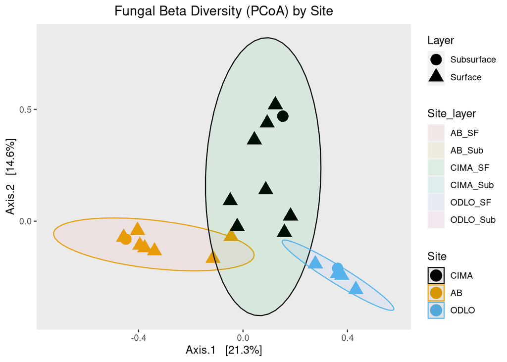

```r
pssitelayer = plot_ordination(physeq.prune.x, physeq.prune.x.ord, type = "samples", color = "Site", shape = "Layer") + ggtitle("Fungal Beta Diversity (PCoA) by Site") + theme(plot.title = element_text(hjust = 0.5)) + geom_point(size=5) + scale_colour_manual(values = c("#000000", "#E69F00", "#56B4E9", "#009E73", "#CC79A7")) + stat_ellipse(geom = "polygon", type = "t", alpha = 1/12, aes(fill = Site_layer)) + theme(panel.grid.major = element_blank(), panel.grid.minor = element_blank())

pssitelayer
```

```r
pdf("./Figures/Fungal Beta Diversity (PCoA) by Site (w Layer).pdf", width = 8, height = 5)
pssitelayer
```

```
## Too few points to calculate an ellipse
## Too few points to calculate an ellipse
## Too few points to calculate an ellipse
```

```r
dev.off()
```

```r
png("./Figures/Fungal Beta Diversity (PCoA) by Site (w Layer).png", units="in", width = 8, height = 5, res = 300 )
pssitelayer
```

```
## Too few points to calculate an ellipse
## Too few points to calculate an ellipse
## Too few points to calculate an ellipse
```

```r
dev.off()
```

###Beta by Crust type

```r
physeq.prune.x = prune_taxa(taxa_sums(physeq.prune.rarefy) > 10, physeq.prune.rarefy)
#physeq.prune.x.SF = subset_samples(physeq.prune.x, Layer=="Surface")
physeq.prune.x.ord <- ordinate(physeq.prune.x, "PCoA", "bray")
```

```r
sample_data(physeq.prune.x)$Crust_type = factor(sample_data(physeq.prune.x)$Crust_type, levels = c("SMC","SMC.ster", "dirt", "SMC.Sub"))
```

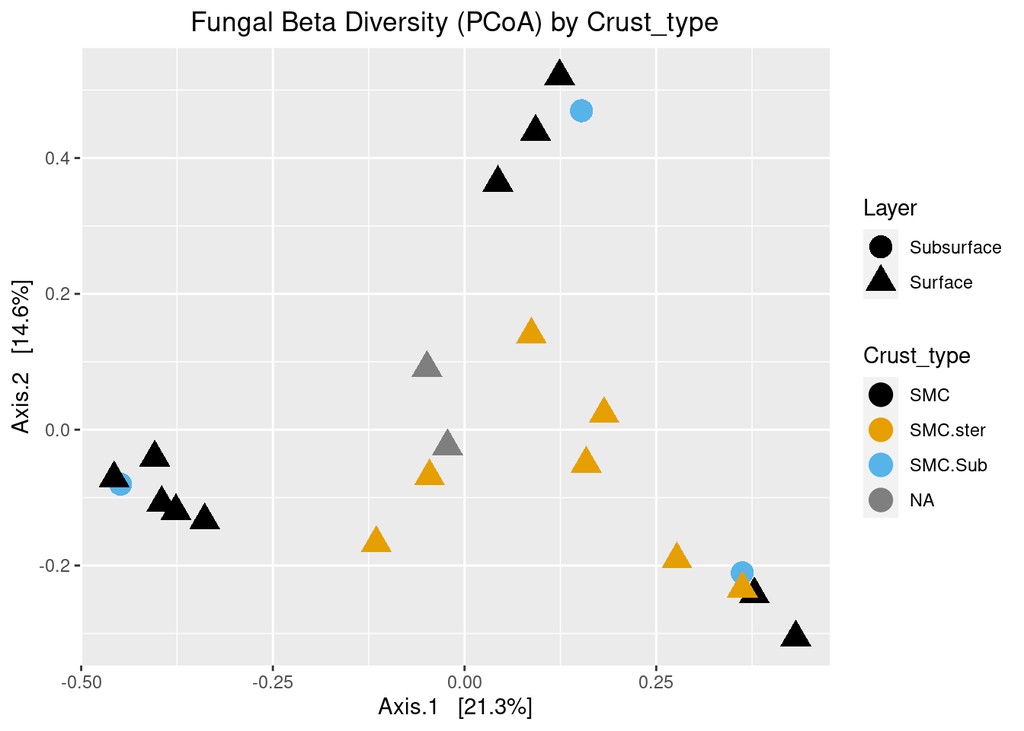

```r
pscrusttype = plot_ordination(physeq.prune.x, physeq.prune.x.ord, type = "samples", color = "Crust_type", shape = "Layer") + ggtitle("Fungal Beta Diversity (PCoA) by Crust_type") + theme(plot.title = element_text(hjust = 0.5)) + geom_point(size=5) + scale_colour_manual(values = c("#000000", "#E69F00", "#56B4E9", "#009E73", "#CC79A7", "#000000", "#E69F00", "#56B4E9", "#009E73", "#CC79A7")) #+ stat_ellipse(geom = "polygon", type = "t", alpha = 1/12, aes(fill = Site_layer))

pscrusttype
```

```r
pdf("./Figures/Fungal Beta Diversity (PCoA) by Crust type.pdf", width = 8, height = 5)
pscrusttype
dev.off()
```

```r
png("./Figures/Fungal Beta Diversity (PCoA) by Crust type.png", units="in", width = 8, height = 5, res = 300 )
pscrusttype
dev.off()
```

```
## Too few points to calculate an ellipse
## Too few points to calculate an ellipse
```

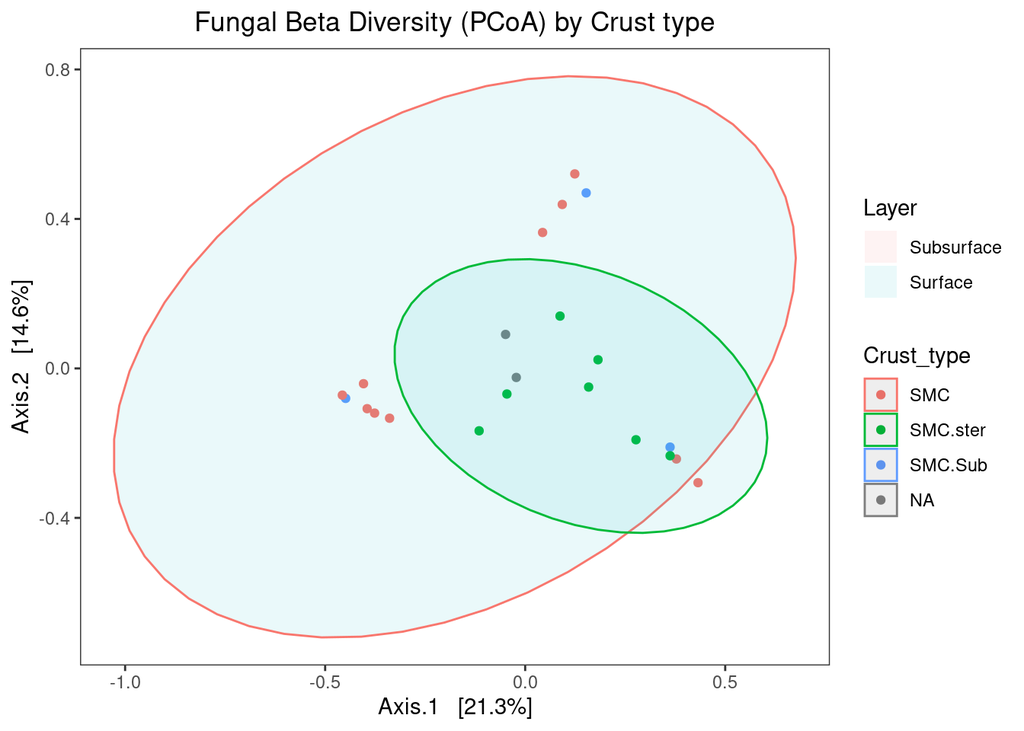

```r
pscrusttype = plot_ordination(physeq.prune.x, physeq.prune.x.ord, type = "samples", color = "Crust_type")  + theme_bw() + ggtitle("Fungal Beta Diversity (PCoA) by Crust type") + theme(plot.title = element_text(hjust = 0.5)) + stat_ellipse(geom = "polygon", alpha = 1/12, aes(fill = Layer)) + theme(panel.grid.major = element_blank(), panel.grid.minor = element_blank())

pscrusttype
```

```r
pdf("./Figures/Fungal Beta Diversity (PCoA) by Crust type.pdf")
pscrusttype
```

```
## Too few points to calculate an ellipse
## Too few points to calculate an ellipse
```

```r
dev.off()
```

###STEP12: Beta diversity (Glomeromycetes)

```r
physeq.prune.Glomeromycetes = subset_taxa(physeq.prune, Class == "Glomeromycetes")
physeq.prune.Glomeromycetes
```

```
## phyloseq-class experiment-level object
## otu_table()   OTU Table:         [ 30 taxa and 22 samples ]
## sample_data() Sample Data:       [ 22 samples by 11 sample variables ]
## tax_table()   Taxonomy Table:    [ 30 taxa by 7 taxonomic ranks ]
```

```r
physeq.prune.rarefy.Glomeromycetes = subset_taxa(physeq.prune.rarefy, Class == "Glomeromycetes")
physeq.prune.rarefy.Glomeromycetes
```

```
## phyloseq-class experiment-level object
## otu_table()   OTU Table:         [ 30 taxa and 22 samples ]
## sample_data() Sample Data:       [ 22 samples by 11 sample variables ]
## tax_table()   Taxonomy Table:    [ 30 taxa by 7 taxonomic ranks ]
```

```r
ps.dist = phyloseq::distance(physeq.prune.Glomeromycetes, "bray")
```

```r
adonis(ps.dist ~ Site*Layer*Crust_type, as(sample_data(physeq.prune.Glomeromycetes),"data.frame"))
```

```
## 'adonis' will be deprecated: use 'adonis2' instead
```

```
## $aov.tab
## Permutation: free
## Number of permutations: 999
##
## Terms added sequentially (first to last)
##
##                 Df SumsOfSqs MeanSqs F.Model      R2 Pr(>F)
## Site             2    0.3220 0.16101 0.86264 0.08036  0.677
## Layer            1    0.2202 0.22017 1.17960 0.05494  0.280
## Crust_type       2    0.4654 0.23268 1.24660 0.11613  0.209
## Site:Layer       2    0.4122 0.20613 1.10432 0.10287  0.362
## Site:Crust_type  2    0.3477 0.17386 0.93144 0.08677  0.558
## Residuals       12    2.2398 0.18665         0.55893
## Total           21    4.0074                 1.00000
##
```

[output cut: 1239 more lines]

```r
adonis(ps.dist ~ Crust_type, as(sample_data(physeq.prune.Glomeromycetes),"data.frame"))
```

```
## 'adonis' will be deprecated: use 'adonis2' instead
```

```
## $aov.tab
## Permutation: free
## Number of permutations: 999
##
## Terms added sequentially (first to last)
##
##            Df SumsOfSqs MeanSqs F.Model      R2 Pr(>F)
## Crust_type  3    0.6699 0.22329  1.2043 0.16716  0.221
## Residuals  18    3.3375 0.18541         0.83284
## Total      21    4.0074                 1.00000
##
## $call
## adonis(formula = ps.dist ~ Crust_type, data = as(sample_data(physeq.prune.Glomeromycetes),
##     "data.frame"))
##
```

[output cut: 1078 more lines]

```r
physeq.prune.x.g = prune_taxa(taxa_sums(physeq.prune.rarefy.Glomeromycetes) > 1, physeq.prune.rarefy.Glomeromycetes)
physeq.prune.x.g.ord <- ordinate(physeq.prune.x.g, "PCoA", "bray")
```

```
## Too few points to calculate an ellipse
## Too few points to calculate an ellipse
## Too few points to calculate an ellipse
```

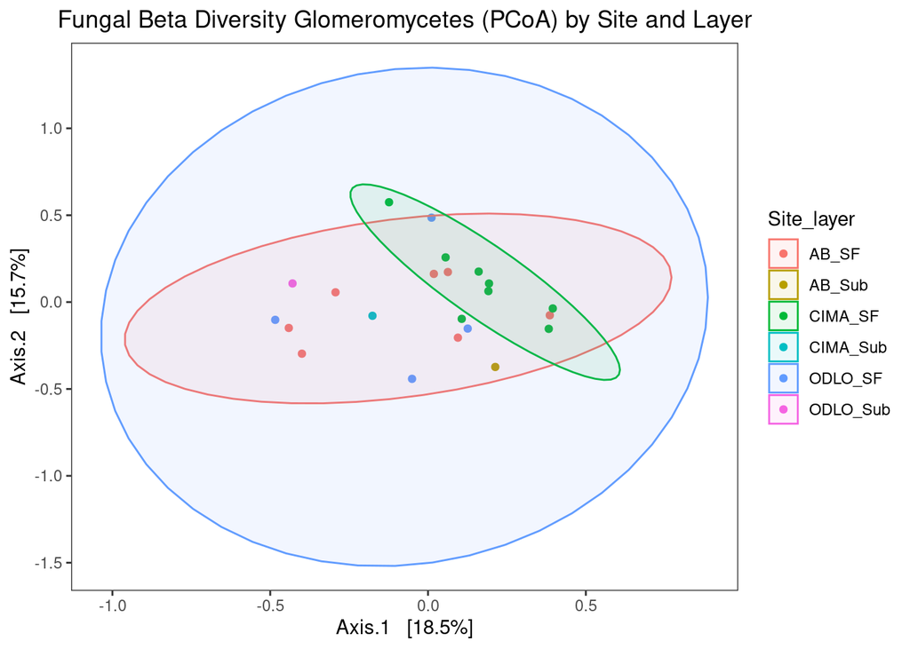

```r
pssitelayerglom = plot_ordination(physeq.prune.x.g, physeq.prune.x.g.ord, type = "samples", color = "Site_layer") + theme_bw() + ggtitle("Fungal Beta Diversity Glomeromycetes (PCoA) by Site and Layer") + theme(plot.title = element_text(hjust = 0.5)) + stat_ellipse(geom = "polygon", alpha = 1/12, aes(fill = Site_layer)) + theme(panel.grid.major = element_blank(), panel.grid.minor = element_blank())

pssitelayerglom
```

```r
pdf("./Figures/Fungal Beta Diversity Glomeromycetes (PCoA) by Site and Layer.pdf")
pssitelayerglom
```

```
## Too few points to calculate an ellipse
## Too few points to calculate an ellipse
## Too few points to calculate an ellipse
```

```r
dev.off()
```

```
## Too few points to calculate an ellipse
## Too few points to calculate an ellipse
```

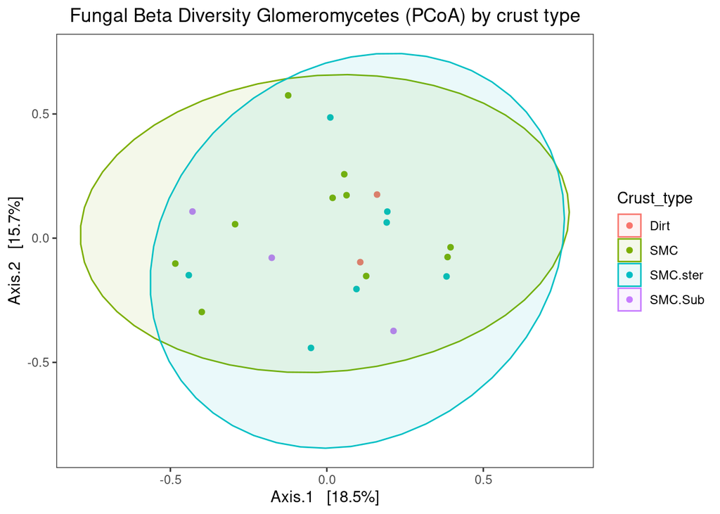

```r
pssitelayerglom22 = plot_ordination(physeq.prune.x.g, physeq.prune.x.g.ord, type = "samples", color = "Crust_type") + theme_bw() + ggtitle("Fungal Beta Diversity Glomeromycetes (PCoA) by crust type") + theme(plot.title = element_text(hjust = 0.5)) + stat_ellipse(geom = "polygon", alpha = 1/12, aes(fill = Crust_type)) + theme(panel.grid.major = element_blank(), panel.grid.minor = element_blank())

pssitelayerglom22
```

```r
pdf("./Figures/Fungal Beta Diversity Glomeromycetes (PCoA) by Crust type.pdf")
pssitelayerglom22
```

```
## Too few points to calculate an ellipse
## Too few points to calculate an ellipse
```

```r
dev.off()
```

###STEP13: Beta diversity (Rhodotorula)

```r
physeq.prune.Rhodo = subset_taxa(physeq.prune, Genus == "Rhodotorula")
physeq.prune.Rhodo
```

```
## phyloseq-class experiment-level object
## otu_table()   OTU Table:         [ 25 taxa and 22 samples ]
## sample_data() Sample Data:       [ 22 samples by 11 sample variables ]
## tax_table()   Taxonomy Table:    [ 25 taxa by 7 taxonomic ranks ]
```

```r
physeq.prune.rarefy.Rhodo = subset_taxa(physeq.prune.rarefy, Genus == "Rhodotorula")
physeq.prune.rarefy.Rhodo
```

```
## phyloseq-class experiment-level object
## otu_table()   OTU Table:         [ 25 taxa and 22 samples ]
## sample_data() Sample Data:       [ 22 samples by 11 sample variables ]
## tax_table()   Taxonomy Table:    [ 25 taxa by 7 taxonomic ranks ]
```

```r
ps.dist = phyloseq::distance(physeq.prune.Rhodo, "bray")
```

```r
adonis(ps.dist ~ Site*Layer*Crust_type, as(sample_data(physeq.prune.Rhodo),"data.frame"))
```

```
## 'adonis' will be deprecated: use 'adonis2' instead
```

```
## $aov.tab
## Permutation: free
## Number of permutations: 999
##
## Terms added sequentially (first to last)
##
##                 Df SumsOfSqs MeanSqs F.Model      R2 Pr(>F)
## Site             2    0.4864 0.24319 0.99796 0.08366  0.415
## Layer            1    0.6811 0.68112 2.79507 0.11715  0.022 *
## Crust_type       2    0.7270 0.36350 1.49167 0.12504  0.174
## Site:Layer       2    0.3583 0.17914 0.73511 0.06162  0.718
## Site:Crust_type  2    0.6369 0.31846 1.30683 0.10955  0.229
## Residuals       12    2.9242 0.24369         0.50297
## Total           21    5.8139                 1.00000
## ---
```

[output cut: 1241 more lines]

```r
adonis(ps.dist ~ Crust_type, as(sample_data(physeq.prune.Rhodo),"data.frame"))
```

```
## 'adonis' will be deprecated: use 'adonis2' instead
```

```
## $aov.tab
## Permutation: free
## Number of permutations: 999
##
## Terms added sequentially (first to last)
##
##            Df SumsOfSqs MeanSqs F.Model      R2 Pr(>F)
## Crust_type  3    1.4322 0.47740  1.9612 0.24634  0.044 *
## Residuals  18    4.3817 0.24343         0.75366
## Total      21    5.8139                 1.00000
## ---
## Signif. codes:  0 '***' 0.001 '**' 0.01 '*' 0.05 '.' 0.1 ' ' 1
##
## $call
## adonis(formula = ps.dist ~ Crust_type, data = as(sample_data(physeq.prune.Rhodo),
```

[output cut: 1080 more lines]

```r
physeq.prune.x.r = prune_taxa(taxa_sums(physeq.prune.rarefy.Rhodo) > 1, physeq.prune.rarefy.Rhodo)
physeq.prune.x.r.ord <- ordinate(physeq.prune.x.r, "PCoA", "bray")
```

```
## Too few points to calculate an ellipse
## Too few points to calculate an ellipse
## Too few points to calculate an ellipse
```

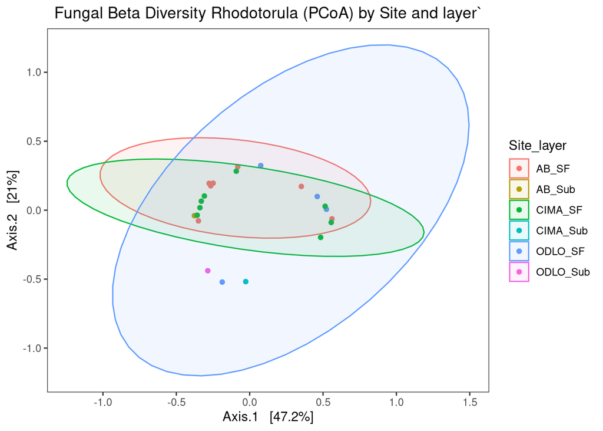

```r
pssitelayerrhodo = plot_ordination(physeq.prune.x.r, physeq.prune.x.r.ord, type = "samples", color = "Site_layer") + theme_bw() + ggtitle("Fungal Beta Diversity Rhodotorula (PCoA) by Site and layer`") + theme(plot.title = element_text(hjust = 0.5)) + stat_ellipse(geom = "polygon", alpha = 1/12, aes(fill = Site_layer)) + theme(panel.grid.major = element_blank(), panel.grid.minor = element_blank())

pssitelayerrhodo
```

```r
pdf("./Figures/Fungal Beta Diversity Rhodotorula (PCoA) by Site and Layer.pdf")
pssitelayerrhodo
```

```
## Too few points to calculate an ellipse
## Too few points to calculate an ellipse
## Too few points to calculate an ellipse
```

```r
dev.off()
```

```
## Too few points to calculate an ellipse
```

```
## Too few points to calculate an ellipse
```

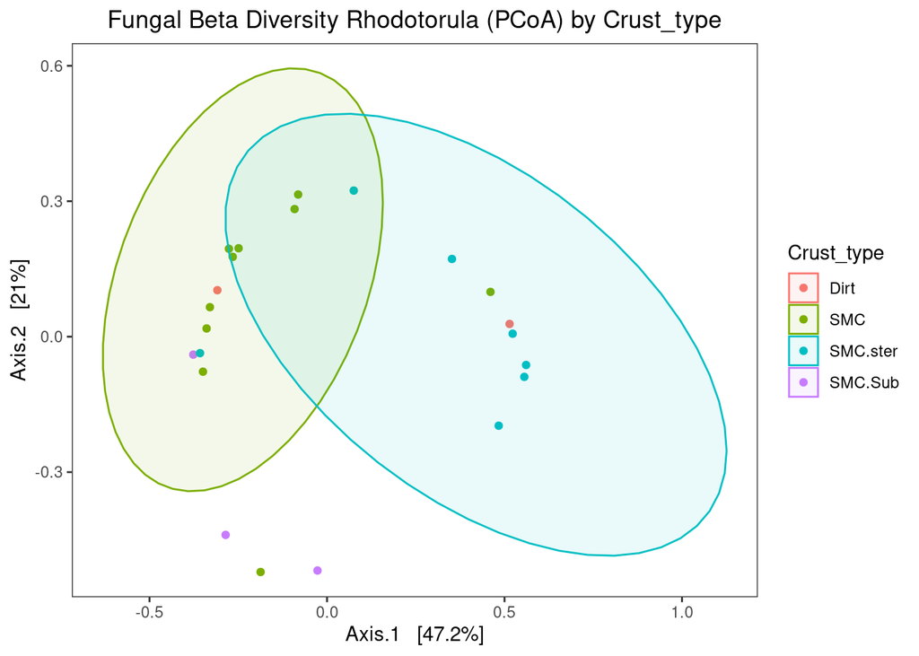

```r
pscrusttyperhodo = plot_ordination(physeq.prune.x.r, physeq.prune.x.r.ord, type = "samples", color = "Crust_type") + theme_bw() + ggtitle("Fungal Beta Diversity Rhodotorula (PCoA) by Crust_type") + theme(plot.title = element_text(hjust = 0.5)) + stat_ellipse(geom = "polygon", alpha = 1/12, aes(fill = Crust_type)) + theme(panel.grid.major = element_blank(), panel.grid.minor = element_blank())

pscrusttyperhodo
```

```r
pdf("./Figures/Fungal Beta Diversity Rhodotorula (PCoA) by Crust Type.pdf")
pssitelayerrhodo
```

```
## Too few points to calculate an ellipse
## Too few points to calculate an ellipse
## Too few points to calculate an ellipse
```

```r
dev.off()
```

###STEP13: Beta diversity (Naganishia)

```r
physeq.prune.Naga = subset_taxa(physeq.prune, Genus == "Naganishia")
physeq.prune.Naga
```

```
## phyloseq-class experiment-level object
## otu_table()   OTU Table:         [ 20 taxa and 22 samples ]
## sample_data() Sample Data:       [ 22 samples by 11 sample variables ]
## tax_table()   Taxonomy Table:    [ 20 taxa by 7 taxonomic ranks ]
```

```r
physeq.prune.rarefy.Naga = subset_taxa(physeq.prune.rarefy, Genus == "Naganishia")
physeq.prune.rarefy.Naga
```

```
## phyloseq-class experiment-level object
## otu_table()   OTU Table:         [ 20 taxa and 22 samples ]
## sample_data() Sample Data:       [ 22 samples by 11 sample variables ]
## tax_table()   Taxonomy Table:    [ 20 taxa by 7 taxonomic ranks ]
```

```r
ps.dist = phyloseq::distance(physeq.prune.Naga, "bray")
```

```r
adonis(ps.dist ~ Site*Layer*Crust_type, as(sample_data(physeq.prune.Naga),"data.frame"))
```

```
## 'adonis' will be deprecated: use 'adonis2' instead
```

```
## $aov.tab
## Permutation: free
## Number of permutations: 999
##
## Terms added sequentially (first to last)
##
##                 Df SumsOfSqs MeanSqs F.Model      R2 Pr(>F)
## Site             2    1.2055 0.60276 2.74294 0.18121  0.002 **
## Layer            1    0.1545 0.15448 0.70298 0.02322  0.694
## Crust_type       2    1.2428 0.62142 2.82788 0.18682  0.004 **
## Site:Layer       2    0.5707 0.28537 1.29865 0.08579  0.239
## Site:Crust_type  2    0.8420 0.42100 1.91582 0.12657  0.031 *
## Residuals       12    2.6370 0.21975         0.39639
## Total           21    6.6525                 1.00000
## ---
```

[output cut: 1241 more lines]

```r
adonis(ps.dist ~ Crust_type, as(sample_data(physeq.prune.Naga),"data.frame"))
```

```
## 'adonis' will be deprecated: use 'adonis2' instead
```

```
## $aov.tab
## Permutation: free
## Number of permutations: 999
##
## Terms added sequentially (first to last)
##
##            Df SumsOfSqs MeanSqs F.Model      R2 Pr(>F)
## Crust_type  3    1.5097 0.50323  1.7613 0.22694   0.03 *
## Residuals  18    5.1428 0.28571         0.77306
## Total      21    6.6525                 1.00000
## ---
## Signif. codes:  0 '***' 0.001 '**' 0.01 '*' 0.05 '.' 0.1 ' ' 1
##
## $call
## adonis(formula = ps.dist ~ Crust_type, data = as(sample_data(physeq.prune.Naga),
```

[output cut: 1080 more lines]

```r
physeq.prune.x.n = prune_taxa(taxa_sums(physeq.prune.rarefy.Naga) > 1, physeq.prune.rarefy.Naga)
physeq.prune.x.n.ord <- ordinate(physeq.prune.x.n, "PCoA", "bray")
```

```
## Too few points to calculate an ellipse
## Too few points to calculate an ellipse
## Too few points to calculate an ellipse
```

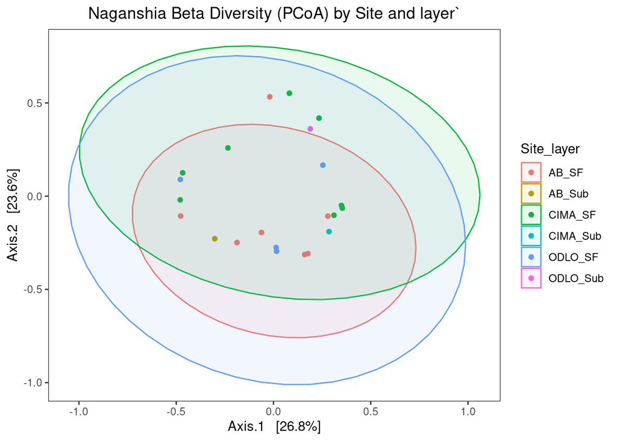

```r
pssitelayernag = plot_ordination(physeq.prune.x.n, physeq.prune.x.n.ord, type = "samples", color = "Site_layer") + theme_bw() + ggtitle("Naganshia Beta Diversity (PCoA) by Site and layer`") + theme(plot.title = element_text(hjust = 0.5)) + stat_ellipse(geom = "polygon", alpha = 1/12, aes(fill = Site_layer)) + theme(panel.grid.major = element_blank(), panel.grid.minor = element_blank())

pssitelayernag
```

```r
pdf("./Figures/Fungal Beta Diversity Naganishia (PCoA) by Site and Layer.pdf")
pssitelayernag
```

```
## Too few points to calculate an ellipse
## Too few points to calculate an ellipse
## Too few points to calculate an ellipse
```

```r
dev.off()
```

```
## Too few points to calculate an ellipse
## Too few points to calculate an ellipse
```

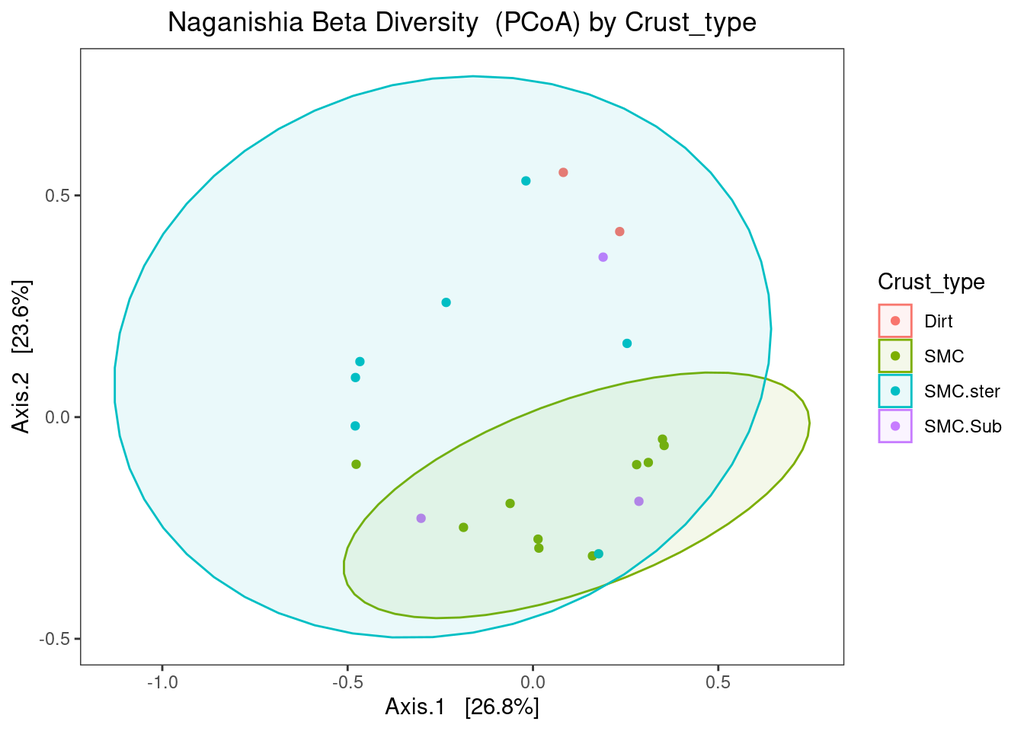

```r
pscrusttypenag = plot_ordination(physeq.prune.x.n, physeq.prune.x.n.ord, type = "samples", color = "Crust_type") + theme_bw() + ggtitle("Naganishia Beta Diversity  (PCoA) by Crust_type") + theme(plot.title = element_text(hjust = 0.5)) + stat_ellipse(geom = "polygon", alpha = 1/12, aes(fill = Crust_type)) + theme(panel.grid.major = element_blank(), panel.grid.minor = element_blank())

pscrusttypenag
```

```r
pdf("./Figures/Fungal Beta Diversity Naganishia (PCoA) by Crust type.pdf")
pscrusttypenag
```

```
## Too few points to calculate an ellipse
## Too few points to calculate an ellipse
```

```r
dev.off()
```